# Comparison Word2Vec Analysis

Isaac Scheinfeld

2018-08-28

# Preparation

This analysis requires a working copy of CFinder and the CFinder license in the same directory (necessary for running CFinder). The following must point to the command line executable:

```r
cfinder_program <- "./CFinder_commandline_mac"
```

## Nouns

We begin with roughly the same data used by Hills. *(TODO fix, get same data)*

```r
# We begin by importing data from wordbank. Age of aquisition (in months, it starts with 16, 17,..) is that at which 50% of children can produce the word. We also do naive triming at this point, this means we are ignoring homophone/polysemy (chiken (food), chiken (animals), etc,.. but we will have to be careful in our choices if we are preparing later for publication.

full_vocab <- make_vocab_dataframe(lang="English (American)",
                                   lang_form = "WS",
                                   lex_class = "nouns") %>%
  trim_all_unilemma() %>%
  trim_all_definition() %>%
  arrange(age) %>%            # keep first age for duplicates
  distinct(uni_lemma, .keep_all = TRUE) %>%
  select(uni_lemma, definition, age, category)
```

The initial vocabulary contains 288 (compared to Hills’ 312).

## Features and Word2Vec

Features taken from McRae et al. (2005), in which features were collected for 541 nouns from 725 adults, with 30 adults providing 14 features for each noun. Word2Vec similarities are from child directed speach (source Abdellah).

```r
vocab <- full_vocab %>%
  filter(age <= 30) %>%
  filter_to_features() %>%
  filter_to_w2v()
```

Filtering to this data gives a vocab of 108.

## Build Network

Using this vocabulary, we construct a network with edge attributes for features, and for word2vec similarity.

```r
# perceptual and conceptual McRae feature types
perceptual_features = c("sound", "taste", "smell", "tactile",
                        "visual-form_and_surface", "visual-motion", "visual-color")
conceptual_features = c("function")

# count shared features between words in vocabulary
feature_links <- make_feature_links(vocab = vocab,
                                    feature_types = union(perceptual_features,
                                                          conceptual_features))

# get word2vec distance between words in vocabulary
w2v_links <- make_w2v_links(vocab = vocab) #TODO still problem w/ vocab matching w2v data

links <- full_join(feature_links, w2v_links, by=c("from", "to"))

network <- graph_from_data_frame(links, vertices = vocab, directed = FALSE) %>%
  as_tbl_graph() %E>%
  mutate(shared = replace_na(shared, as.integer(0))) # is this replacement necessary?
```

# Results

## Word2Vec vs Feature Network

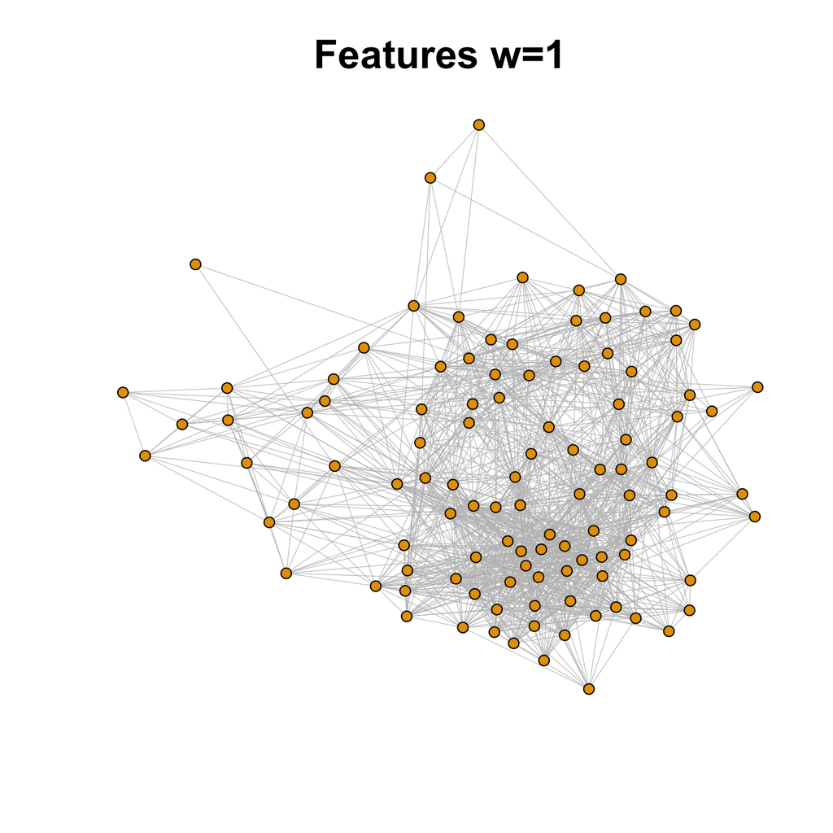

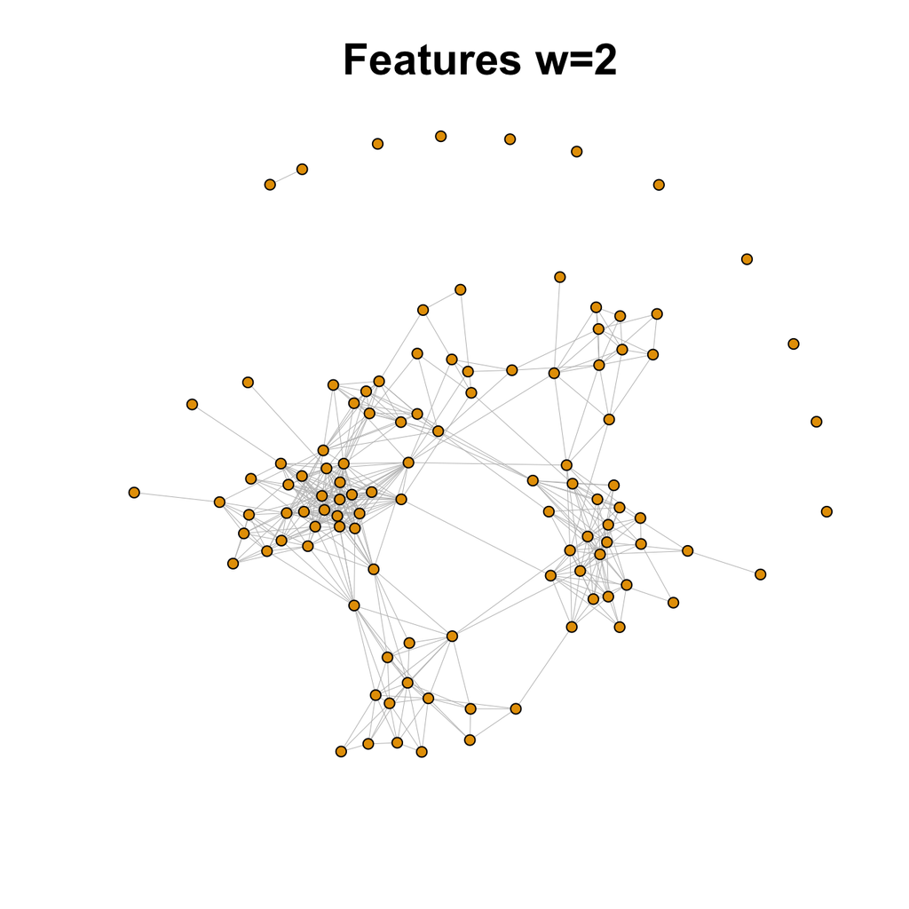

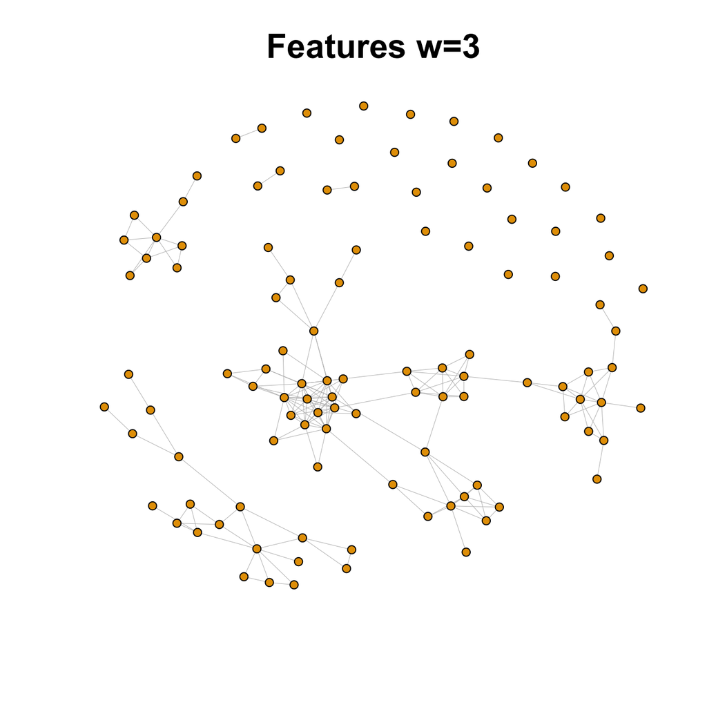

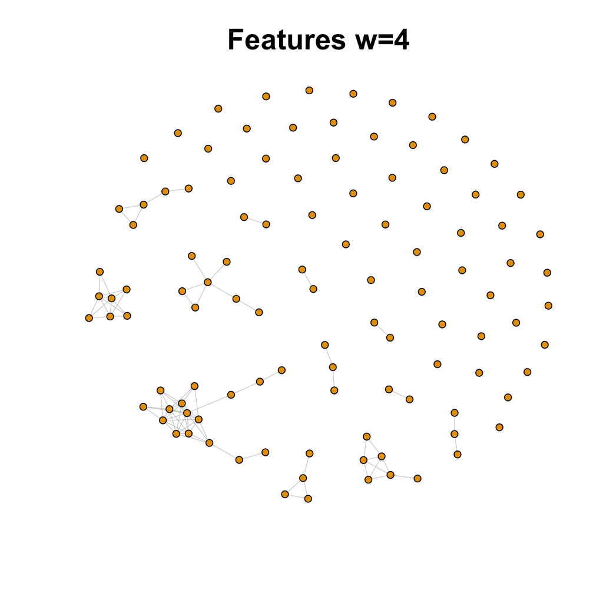

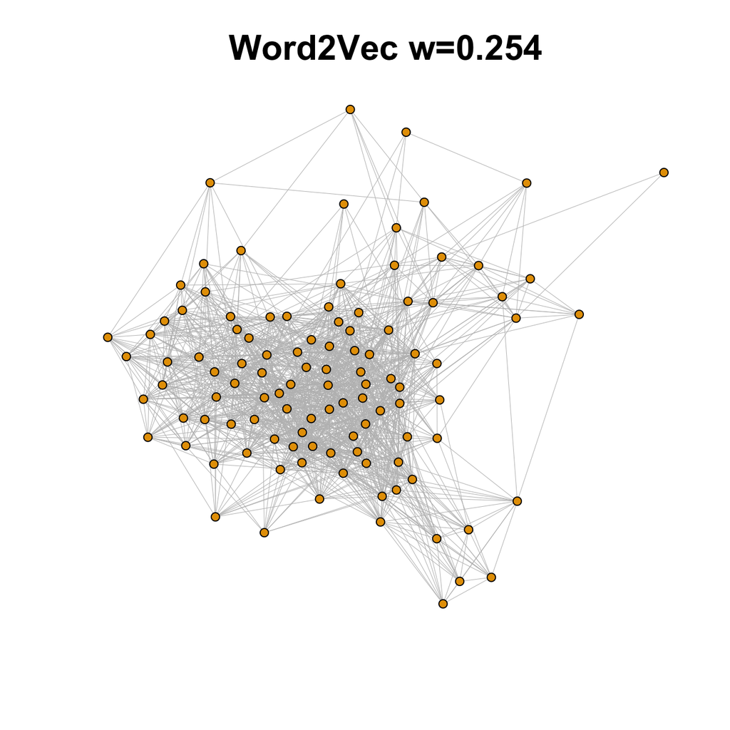

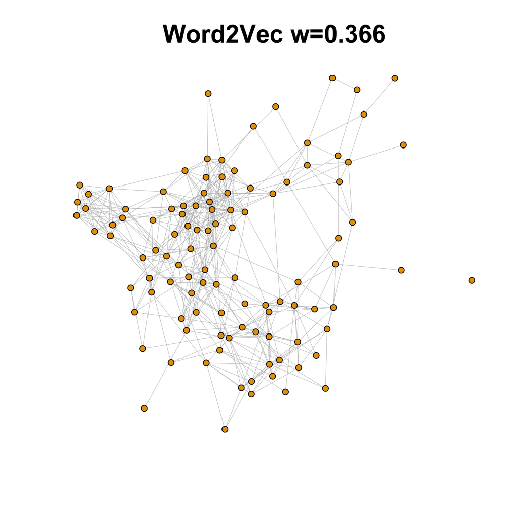

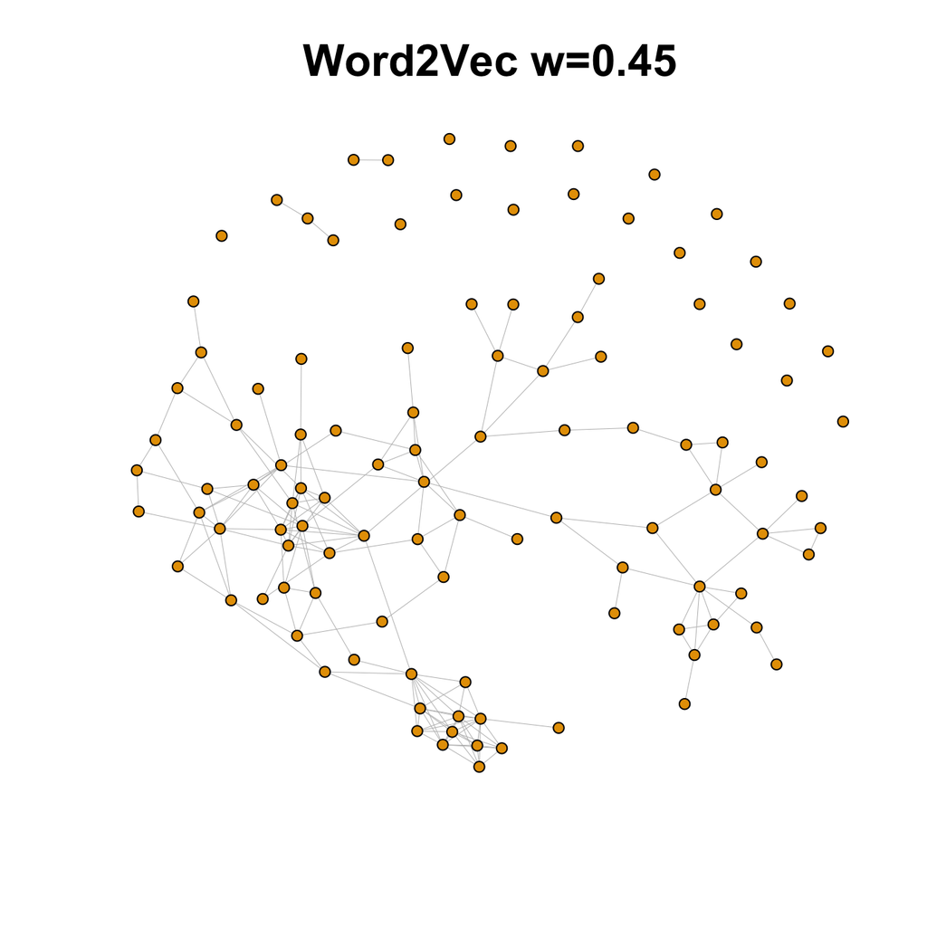

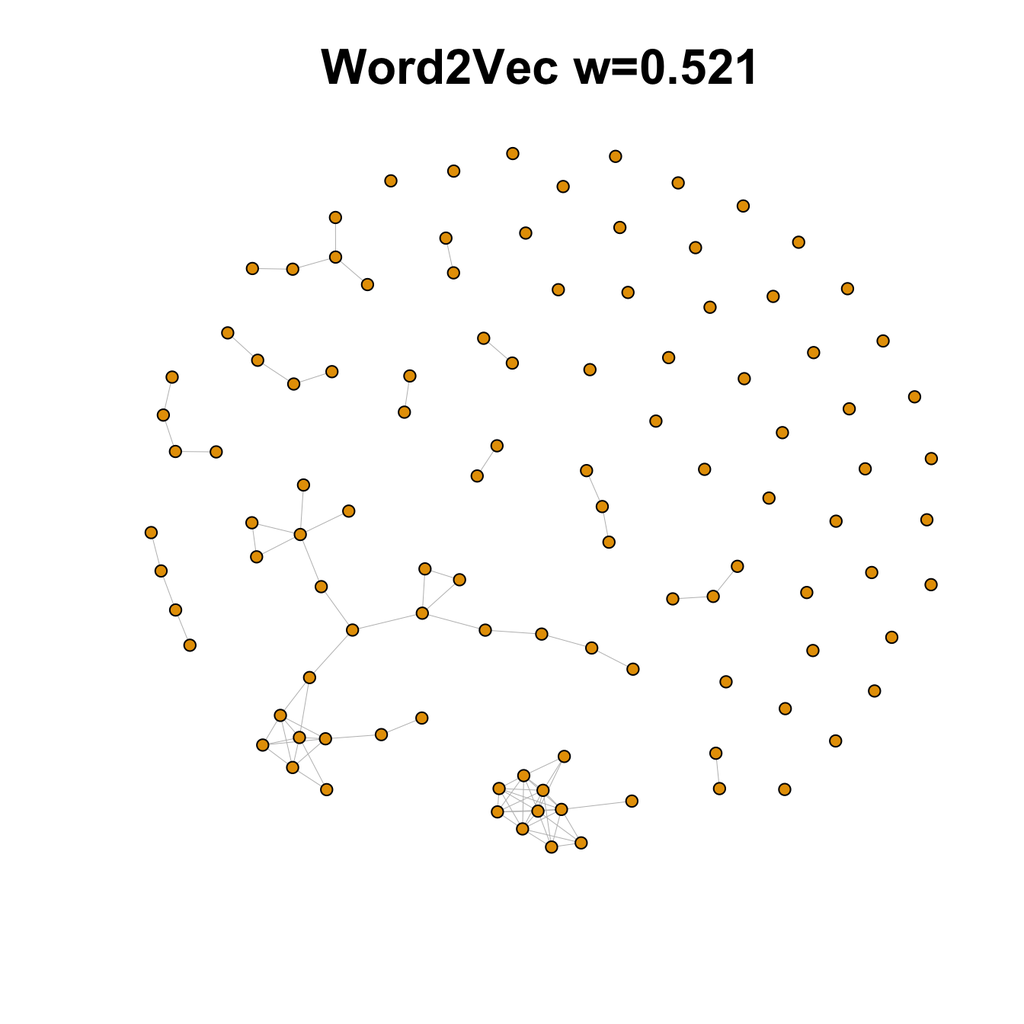

```r
par(oma=c(0,0,0.2,0))

ecounts <- list()
for (w in 1:4) {
  net <- network %E>% filter(shared >= w)
  ecounts[[length(ecounts) + 1]] <- ecount(net)
  layout <- layout_with_fr(net)
  plot_vocab_network(net,
                     plot_title = title(str_glue("Features w={w}"), cex.main = 2),
                     frame=FALSE, layout = layout, labels="")
}

# find thresholds that give matching edge counts
thresholds <- list()
for (i in seq_along(ecounts)) {
  e <- ecounts[[i]]
  curr_pow <- 1
  curr_e <- 0
  curr_t <- 1
  while (as.integer(curr_e) != as.integer(e)) {
    if (curr_e < e) {
      curr_t <- curr_t - (1/2) ^ curr_pow
    } else {
      curr_t <- curr_t + (1/2) ^ curr_pow
    }
    curr_e <- ecount(network %E>% filter(w2v_similarity >= curr_t))
    curr_pow <- curr_pow + 1
  }
  thresholds[[length(thresholds) + 1]] <- curr_t
}

for (w in thresholds) {
  net <- network %E>% filter(w2v_similarity >= w)
  layout <- layout_with_fr(net)
  plot_vocab_network(net, plot_title = title(str_glue("Word2Vec w={format(w,digits=3)}"), cex.main = 2),
                     frame=FALSE, layout = layout, labels="")
}
```

```r
network_properties <- function(network) {
  return( tibble(
    type = network$type,
    w = network$w,
    avg_distance = mean_distance(network),
    clustering_coef = transitivity(network),
    isolates = sum(degree(network) == 0),
    components = count_components(network) - isolates
  ))
}

feature_networks <- map(1:4, function(w) {
  network %>%
    filter(shared >= w) %>%
    set.graph.attribute("type", "Feature") %>%
    set.graph.attribute("w",w)})
w2v_networks <- map(thresholds, function(w) {
  network %>%
    filter(w2v_similarity >= w) %>%
    set.graph.attribute("type", "Word2Vec") %>%
    set.graph.attribute("w",w)}
)

feature_properties <- bind_rows(map(feature_networks, network_properties))
w2v_properties <- bind_rows(map(w2v_networks, network_properties))

bind_rows(feature_properties, w2v_properties) %>%
  kable(format="html",
        escape = FALSE,
        col.names = c("Type", "w",
                      "Clustering Coefficient",
                      "Average length",
                      "Components",
                      "Isolates"),
        align = rep("l",6),
        digits = 2) %>%
  kable_styling(full_width = F) %>%
  collapse_rows(columns = 1, valign = "top")
```

[output not shown]

## Clique Percolation

We can now compare clique percolation on feature and word2vec networks.

```r
best_count <-  0
for (w in 1:5) {
  result <- cluster_cfinder(network %E>% filter(shared >= w),
                            cfinder_program = cfinder_program)
  clusters <- result$clusters
  k <- result$k
  if (length(clusters) > best_count) {
    best_w <- w
    best_k <- k
    best_count <- length(clusters)
    best_clusters <- clusters
  }
}

title <- str_glue("Feature Network Clique Percolation Clusters, w = {best_w} and k = {best_k}")
kable_clusters(best_clusters, title)
```

| Feature Network Clique Percolation Clusters, w = 1 and k = 8 (7 Clusters) |
| --- |
| couch pants belt boots coat jacket gloves shirt |
| banana couch strawberry cheese bread lamb bed napkin pajamas pillow |
| boat hammer table banana airplane couch tractor tricycle pants box bus chicken garage horse pumpkin squirrel alligator peas strawberry apple orange pickle balloon cheese truck bread lamb chair bathtub… |
| table banana pen broom pants alligator belt hose stick boots coat pencil necklace |
| boat hammer airplane tractor tricycle bus chicken helicopter horse squirrel train truck motorcycle car |
| boat hammer table banana airplane pen tractor tricycle broom door helicopter pumpkin spoon train hose peas apple orange pickle balloon basket bucket fork knife oven scissors shovel sink stove bowl clo… |
| boat hammer table pen broom box door garage spoon stick pencil basket chair |

Note:  
Color indicates number of clusters in which a word occurs: 1 2 3 4

We can compare this to the corresponding clustering on the word2vec network with the same density, using the same parameters.

```r
clusters <- cluster_cfinder(network %E>%
                              filter(w2v_similarity >= thresholds[[best_w]]),
                            k = best_k,
                            cfinder_program = cfinder_program)$clusters

title <- str_glue("Word2Vec Network Clique Percolation Clusters, w = {format(thresholds[[best_w]], digits=2)} and k = {best_k}")
kable_clusters(clusters, title)
```

| Word2Vec Network Clique Percolation Clusters, w = 0.25 and k = 8 (2 Clusters) |
| --- |
| boat helicopter radio horse squirrel dog airplane bus chair closet couch garage hose knife lamp motorcycle oven telephone tractor train tricycle stove sink ball balloon basket bathtub bedroom bowl box… |
| boat helicopter radio horse squirrel dog alligator deer elephant penguin rooster zebra turtle cat pig frog cow giraffe goose lion mouse sheep tiger duck lamb |

Note:  
Color indicates number of clusters in which a word occurs: 1 2

We can also search for parameters for the word2vec network using Hills’ approach. Note that w is given a lower bound of 0.25 as below this the network is too dense for cfinder to compute the clusters in a minute or less.

```r
best_count <-  0
for (w in seq(0.25,0.9,0.05)) {
  result <- cluster_cfinder(network %E>% filter(w2v_similarity >= w),
                            cfinder_program = cfinder_program)
  clusters <- result$clusters
  k <- result$k
  if (length(clusters) > best_count) {
    best_w <- w
    best_k <- k
    best_count <- length(clusters)
    best_clusters <- clusters
  }
}

title <- str_glue("Word2Vec Network Clique Percolation Clusters, w = {best_w} and k = {best_k}")
kable_clusters(best_clusters, title)
```

| Word2Vec Network Clique Percolation Clusters, w = 0.3 and k = 7 (9 Clusters) |
| --- |
| chicken bread corn tuna turkey beans peas |
| horse cow sheep pig frog duck rooster lamb |
| radio tricycle pillow shirt spoon bed sweater plate coat necklace jacket mittens pajamas pants belt gloves jeans boots |
| dish car bowl sink chair cup bathtub bed oven basket box bucket closet garage bedroom |
| dish car bowl sink motorcycle stove chair cup pillow shirt spoon chicken napkin sweater plate couch ball crayon fork pencil pen table bottle knife |
| horse car boat motorcycle radio tricycle airplane bus tractor train truck |
| horse cow sheep pig cat duck dog |
| horse cow sheep frog cat dog deer elephant penguin zebra giraffe lion tiger |
| dish bowl sink boat stove bathtub napkin |

Note:  
Color indicates number of clusters in which a word occurs: 1 2 3 4

## Other Clustering Algorithms

We can cluster both the feature and word2vec networks using other clustering algorithms.

### Walktrap

```r
clusters <- cluster_walktrap(network, weights = E(network)$shared) # NA weights are treated as 0
kable_clusters(clusters, title = "Feature Network Walktrap Clusters")
```

| Feature Network Walktrap Clusters (4 Clusters) |
| --- |
| bed shirt pillow coat pants boots jacket pajamas belt sweater necklace gloves jeans mittens |
| ball book bottle apple cup spoon telephone door pen orange bowl clock fork broom plate shovel pencil knife sink basket hammer radio scissors hose stick bucket dish oven stove lamp |
| dog cat duck cheese bear cow horse pig mouse bread chicken frog cake ant butterfly elephant lion tiger turtle beans corn peas pickle raisin owl sheep potato strawberry bedroom giraffe lamb squirrel tu… |
| balloon car banana truck airplane boat train doll chair bus box bathtub motorcycle crayon napkin table helicopter couch alligator pumpkin garage tractor tricycle |

Note:  
Color indicates number of clusters in which a word occurs: 1

```r
clusters <- cluster_walktrap(network, weights = E(network)$w2v_similarity)
kable_clusters(clusters, title = "Word2Vec Network Walktrap Clusters")
```

| Word2Vec Network Walktrap Clusters (4 Clusters) |
| --- |
| banana apple cheese bread chicken cake orange beans corn peas pickle raisin potato strawberry turkey tuna |
| shirt coat pants boots jacket pajamas belt sweater gloves jeans mittens |
| ball balloon book bottle cat car truck airplane boat cup spoon train doll telephone bed chair door pillow bus pen bowl box clock fork bathtub motorcycle crayon broom napkin plate table shovel pencil k… |
| dog duck bear cow horse pig mouse frog ant butterfly elephant lion tiger turtle owl sheep helicopter alligator giraffe lamb squirrel zebra pumpkin deer goose penguin pony rooster |

Note:  
Color indicates number of clusters in which a word occurs: 1

### Louvain

```r
clusters <- cluster_louvain(network, weights = E(network)$shared) # NA weights are treated as 0
kable_clusters(clusters, title = "Feature Network Louvain Clusters")
```

| Feature Network Louvain Clusters (5 Clusters) |
| --- |
| book bed shirt pillow coat pants boots jacket pajamas napkin belt sweater necklace gloves jeans mittens |
| ball balloon bottle cup spoon doll telephone door pen bowl clock fork bathtub crayon broom plate shovel pencil knife sink basket hammer radio scissors hose stick bucket dish oven stove lamp |
| dog cat bear cow horse pig chair mouse frog elephant lion tiger turtle table sheep couch alligator giraffe lamb squirrel zebra deer pony |
| car truck airplane boat train bus box motorcycle helicopter closet garage tractor tricycle |
| duck banana apple cheese bread chicken cake orange ant butterfly beans corn peas pickle raisin owl potato strawberry bedroom turkey pumpkin tuna goose penguin rooster |

Note:  
Color indicates number of clusters in which a word occurs: 1

```r
clusters <- cluster_louvain(network, weights = E(network)$w2v_similarity)
kable_clusters(clusters, title = "Word2Vec Network Louvain Clusters")
```

| Word2Vec Network Louvain Clusters (4 Clusters) |
| --- |
| dog book cat duck bear cow horse pig mouse frog clock ant butterfly elephant lion tiger turtle owl sheep helicopter alligator giraffe lamb squirrel zebra pumpkin deer goose penguin pony rooster |
| shirt pillow coat pants boots jacket pajamas belt sweater necklace gloves jeans mittens |
| banana apple cheese bread chicken cake orange beans corn peas pickle raisin potato strawberry turkey tuna |
| ball balloon bottle car truck airplane boat cup spoon train doll telephone bed chair door bus pen bowl box fork bathtub motorcycle crayon broom napkin plate table shovel pencil knife bedroom couch sin… |

Note:  
Color indicates number of clusters in which a word occurs: 1

### Spinglass

```r
clusters <- cluster_spinglass(network, weights = E(network)$shared) # NA weights are treated as 0
kable_clusters(clusters, title = "Feature Network Spinglass Clusters")
```

| Feature Network Spinglass Clusters (5 Clusters) |
| --- |
| car truck airplane boat train bus box bathtub motorcycle helicopter closet garage tractor tricycle |
| book bed shirt pillow coat pants boots jacket pajamas napkin belt sweater necklace gloves jeans mittens |
| ball balloon bottle cup spoon doll telephone door pen bowl clock fork crayon broom plate shovel pencil knife sink basket hammer radio scissors hose stick bucket dish oven stove lamp |
| duck banana apple cheese bread chicken cake orange ant butterfly beans corn peas pickle raisin owl potato strawberry bedroom turkey pumpkin tuna goose penguin rooster |
| dog cat bear cow horse pig chair mouse frog elephant lion tiger turtle table sheep couch alligator giraffe lamb squirrel zebra deer pony |

Note:  
Color indicates number of clusters in which a word occurs: 1

```r
clusters <- cluster_spinglass(network, weights = E(network)$w2v_similarity)
kable_clusters(clusters, title = "Word2Vec Network Spinglass Clusters")
```

| Word2Vec Network Spinglass Clusters (4 Clusters) |
| --- |
| bottle banana cheese cup spoon bread chicken cake orange bowl fork beans corn peas pickle raisin napkin plate potato strawberry knife turkey dish tuna |
| dog book cat duck apple bear cow horse pig mouse frog clock ant butterfly elephant lion tiger turtle owl sheep helicopter alligator giraffe lamb squirrel zebra pumpkin deer goose penguin pony rooster |
| ball balloon car truck airplane boat train doll telephone bed chair door bus pen box bathtub motorcycle crayon broom table shovel pencil bedroom couch sink basket hammer radio scissors closet garage h… |
| shirt pillow coat pants boots jacket pajamas belt sweater necklace tricycle gloves jeans mittens |

Note:  
Color indicates number of clusters in which a word occurs: 1